# Homework2

Ahmet Mert Pulçu

07 05 2021

# **Forecasting House Sales of April 2021**

## INTRODUCTION

In this homework, I will try to forecast the number of total house sales of April 2021. I will build a time series regression model in order to do this forecasting. The aim is reaching the model which has residuals with zero mean and constant variance. Minimizing autocorrelation is another objective of this study.

## Introducing and Visualizing the Data

```r
house_sales_data<-read_excel("house_sales.xlsx")
house_sales_data<-ts(house_sales_data,frequency = 12,start = c(2013,1))
head(house_sales_data)
```

```
##         Jan    Feb    Mar    Apr    May    Jun
## 2013  87444  88519  97956  95381 103261  96424
```

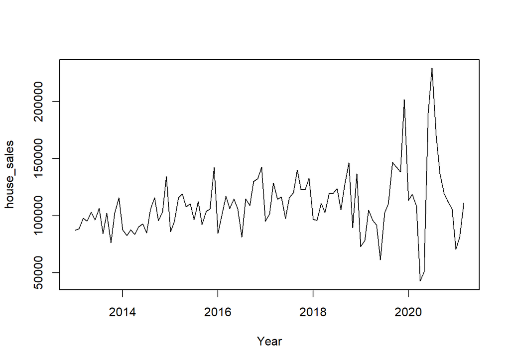

```r
plot(house_sales_data,xlab="Year")
```

```r
house_sales<-data.table(sales=house_sales_data)
house_sales[,trend:=1:.N]
head(house_sales)
```

```
##    sales.house_sales trend
## 1:             87444     1
## 2:             88519     2
## 3:             97956     3
## 4:             95381     4
## 5:            103261     5
## 6:             96424     6
```

```r
ts_reg=lm(sales.house_sales~trend,data=house_sales)
summary(ts_reg)
```

```
##
## Call:
## lm(formula = sales.house_sales ~ trend, data = house_sales)
##
## Residuals:
##    Min     1Q Median     3Q    Max
## -77328 -12337   -979  10658 108416
##
## Coefficients:
##             Estimate Std. Error t value Pr(>|t|)
## (Intercept) 95741.05    5328.83  17.967  < 2e-16 ***
## trend         276.93      92.53   2.993  0.00351 **
## ---
## Signif. codes:  0 '***' 0.001 '**' 0.01 '*' 0.05 '.' 0.1 ' ' 1
##
## Residual standard error: 26310 on 97 degrees of freedom
## Multiple R-squared:  0.08454,    Adjusted R-squared:  0.0751
## F-statistic: 8.957 on 1 and 97 DF,  p-value: 0.003506
```

The mean residual, R-squared values are not satisfactory. Therefore we need to introduce other predictors to our model as well.

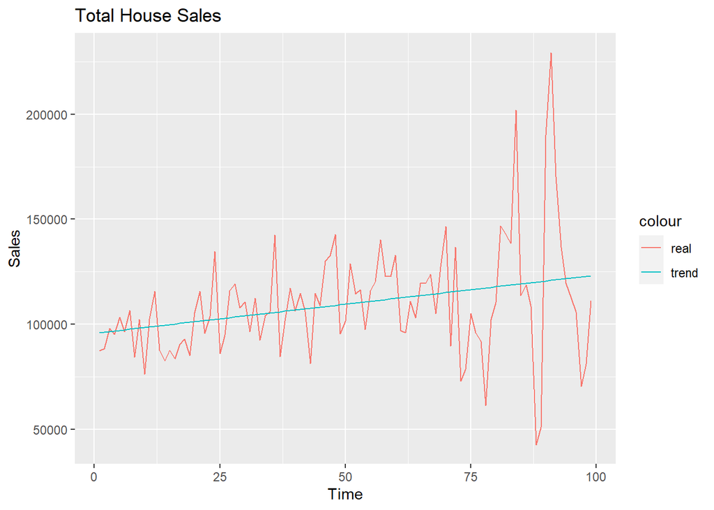

```r
house_sales[,trend_constant:=predict(ts_reg,house_sales)]
 ggplot(house_sales ,aes(x=trend)) +
 geom_line(aes(y=sales.house_sales,color='real')) +
 geom_line(aes(y=trend_constant,color='trend')) + labs(title = "Total House Sales", x = "Time",y = "Sales")
```

Trend data is not sufficient to explain the fluctuations beginning at 2019.

## Adding Predictors

I will use month,interest rate for housing loans, and financial situation of the household data as predictors. I am adding those data to my house sales data.

```r
month<-seq(1,12,by=1)
financial_st<-read_excel("financial_st.xlsx")
interest_housing<-read_excel("interest_housing.xlsx")
interest_housing<-data.table(interest_housing)
financial_st<-data.table(financial_st)
house_sales<-cbind(house_sales,month,interest_housing,financial_st)
house_sales$Date<-as.yearmon(house_sales$Date)
head(house_sales)
```

```
##    sales.house_sales trend trend_constant month interest_housing financial_st
## 1:             87444     1       96017.97     1           9.7750        75.44
## 2:             88519     2       96294.90     2           9.5775        75.03
## 3:             97956     3       96571.83     3           9.3060        74.61
## 4:             95381     4       96848.75     4           9.0575        76.12
## 5:            103261     5       97125.68     5           8.7660        76.80
## 6:             96424     6       97402.61     6           8.2975        75.96
##        Date
## 1: Oca 2013
## 2: Şub 2013
## 3: Mar 2013
## 4: Nis 2013
## 5: May 2013
## 6: Haz 2013
```

# Regression Analysis

## Seasonality Analysis

```r
fit<-lm(sales.house_sales~trend+as.factor(month),data = house_sales)
summary(fit)
```

```
##
## Call:
## lm(formula = sales.house_sales ~ trend + as.factor(month), data = house_sales)
##
## Residuals:
##    Min     1Q Median     3Q    Max
## -62956 -10606    792  10969 101123
##
## Coefficients:
##                    Estimate Std. Error t value Pr(>|t|)
## (Intercept)        75996.20    9044.57   8.402 8.09e-13 ***
## trend                252.58      84.98   2.972  0.00383 **
## as.factor(month)2   5117.75   11355.24   0.451  0.65334
## as.factor(month)3  20410.40   11356.20   1.797  0.07580 .
## as.factor(month)4   7515.56   11707.16   0.642  0.52261
## as.factor(month)5  11559.10   11705.62   0.987  0.32618
## as.factor(month)6  21200.40   11704.70   1.811  0.07359 .
## as.factor(month)7  29253.57   11704.39   2.499  0.01434 *
## as.factor(month)8  26826.87   11704.70   2.292  0.02435 *
## as.factor(month)9  32464.66   11705.62   2.773  0.00680 **
## as.factor(month)10 28140.08   11707.16   2.404  0.01838 *
## as.factor(month)11 24159.63   11709.32   2.063  0.04210 *
## as.factor(month)12 49568.80   11712.10   4.232 5.77e-05 ***
## ---
## Signif. codes:  0 '***' 0.001 '**' 0.01 '*' 0.05 '.' 0.1 ' ' 1
##
## Residual standard error: 24090 on 86 degrees of freedom
## Multiple R-squared:  0.3197, Adjusted R-squared:  0.2248
## F-statistic: 3.368 on 12 and 86 DF,  p-value: 0.0004739
```

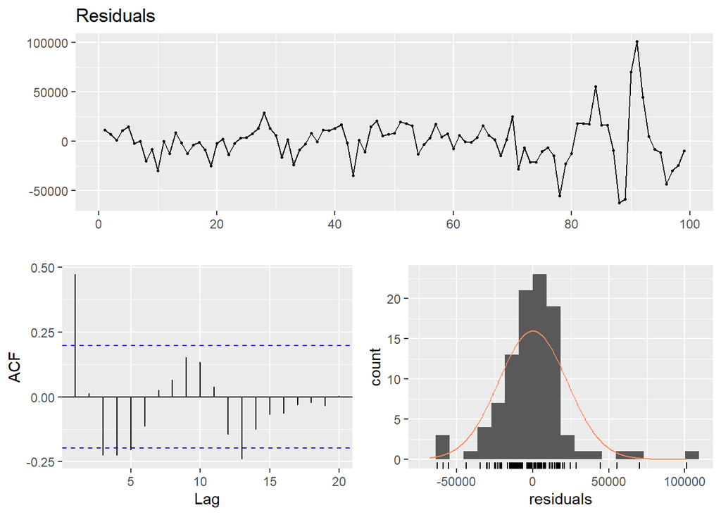

```
##
##  Breusch-Godfrey test for serial correlation of order up to 12
##
## data:  Residuals
## LM test = 40.516, df = 12, p-value = 5.902e-05
```

```r
checkresiduals(fit,lag = 12)
```

It can be said that there is seasonality effect. The effects of the months close to the end of the year have a relatively strong effect on total house sales. However, when we look at R-squared values and the residual standard errors, we see that they are not satisfactory.

## Interest Rates on Housing Loans

```r
fit<-lm(sales.house_sales~trend+as.factor(month)+interest_housing,data= house_sales)
summary(fit)
```

```
##
## Call:
## lm(formula = sales.house_sales ~ trend + as.factor(month) + interest_housing,
##     data = house_sales)
##
## Residuals:
##    Min     1Q Median     3Q    Max
## -72229  -6857    742   8801  85495
##
## Coefficients:
##                     Estimate Std. Error t value Pr(>|t|)
## (Intercept)        100072.36   10814.72   9.253 1.66e-14 ***
## trend                 409.65      90.91   4.506 2.09e-05 ***
## as.factor(month)2    4433.02   10646.56   0.416 0.678181
## as.factor(month)3   18311.40   10661.82   1.717 0.089534 .
## as.factor(month)4    4989.74   10997.33   0.454 0.651185
## as.factor(month)5    9118.34   10994.39   0.829 0.409222
## as.factor(month)6   18031.21   11007.97   1.638 0.105116
## as.factor(month)7   26803.69   10993.40   2.438 0.016845 *
## as.factor(month)8   23561.87   11010.15   2.140 0.035220 *
## as.factor(month)9   31683.28   10975.47   2.887 0.004934 **
## as.factor(month)10  28811.35   10976.35   2.625 0.010277 *
## as.factor(month)11  24526.46   10977.26   2.234 0.028088 *
## as.factor(month)12  50205.06   10980.81   4.572 1.63e-05 ***
## interest_housing    -2226.43     620.82  -3.586 0.000559 ***
## ---
## Signif. codes:  0 '***' 0.001 '**' 0.01 '*' 0.05 '.' 0.1 ' ' 1
##
## Residual standard error: 22580 on 85 degrees of freedom
## Multiple R-squared:  0.4091, Adjusted R-squared:  0.3187
## F-statistic: 4.527 on 13 and 85 DF,  p-value: 8.121e-06
```

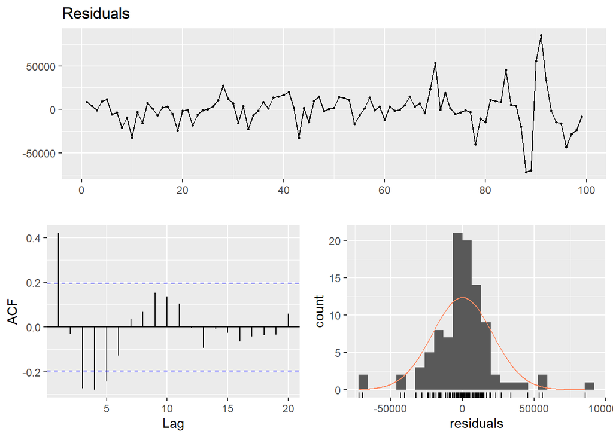

```
##
##  Breusch-Godfrey test for serial correlation of order up to 12
##
## data:  Residuals
## LM test = 36.449, df = 12, p-value = 0.0002743
```

```r
checkresiduals(fit,lag=12)
```

Interest rates have a significant effect in this model. ALthough there is an increase in R-squared values,it is still low.

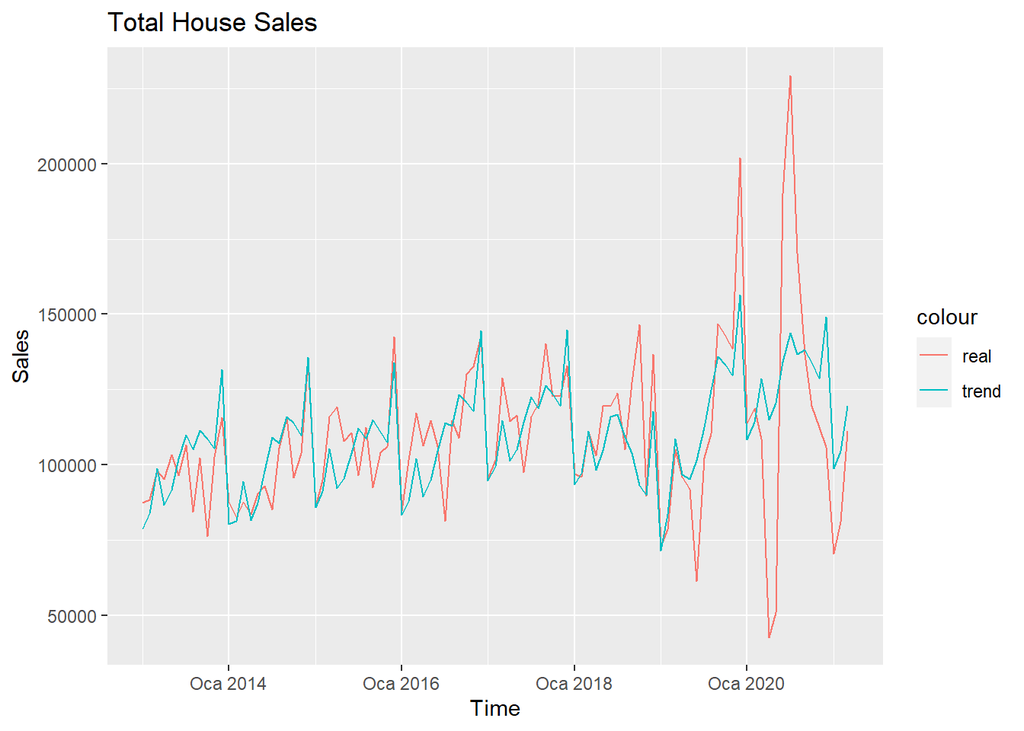

```r
house_sales[,trend_constant_interest:=predict(fit,house_sales)]

ggplot(house_sales ,aes(x=Date)) +
 geom_line(aes(y=sales.house_sales,color='real')) +
 geom_line(aes(y=trend_constant_interest,color='trend')) + labs(title = "Total House Sales", x = "Time",y = "Sales")
```

## Statement of Financial Situation of Households

```r
fit<-lm(sales.house_sales~trend+as.factor(month)+interest_housing+financial_st,data= house_sales)
summary(fit)
```

```
##
## Call:
## lm(formula = sales.house_sales ~ trend + as.factor(month) + interest_housing +
##     financial_st, data = house_sales)
##
## Residuals:
##    Min     1Q Median     3Q    Max
## -75885  -6349    367   8257  83872
##
## Coefficients:
##                    Estimate Std. Error t value Pr(>|t|)
## (Intercept)        155682.1    69241.5   2.248 0.027170 *
## trend                 372.2      102.1   3.647 0.000459 ***
## as.factor(month)2    4269.0    10669.8   0.400 0.690099
## as.factor(month)3   18449.2    10684.5   1.727 0.087893 .
## as.factor(month)4    5925.2    11079.2   0.535 0.594199
## as.factor(month)5    9688.4    11038.7   0.878 0.382623
## as.factor(month)6   19133.1    11112.9   1.722 0.088804 .
## as.factor(month)7   28029.1    11118.0   2.521 0.013590 *
## as.factor(month)8   25034.3    11179.8   2.239 0.027783 *
## as.factor(month)9   31749.5    10997.7   2.887 0.004945 **
## as.factor(month)10  29378.3    11020.4   2.666 0.009210 **
## as.factor(month)11  24170.3    11007.9   2.196 0.030869 *
## as.factor(month)12  49265.6    11063.3   4.453 2.59e-05 ***
## interest_housing    -2269.7      624.3  -3.635 0.000477 ***
## financial_st         -726.2      893.0  -0.813 0.418432
## ---
## Signif. codes:  0 '***' 0.001 '**' 0.01 '*' 0.05 '.' 0.1 ' ' 1
##
## Residual standard error: 22630 on 84 degrees of freedom
## Multiple R-squared:  0.4137, Adjusted R-squared:  0.316
## F-statistic: 4.234 on 14 and 84 DF,  p-value: 1.383e-05
```

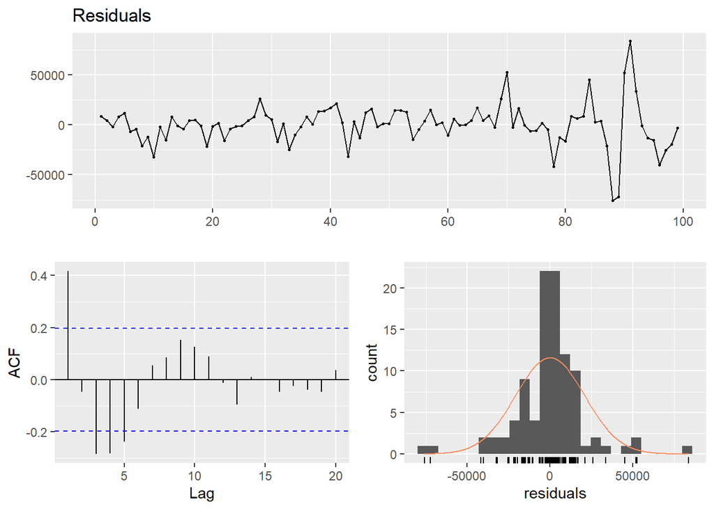

```
##
##  Breusch-Godfrey test for serial correlation of order up to 12
##
## data:  Residuals
## LM test = 35.719, df = 12, p-value = 0.0003594
```

```r
checkresiduals(fit,lag=12)
```

The model shows that there is no significant effect of the data financial_st.

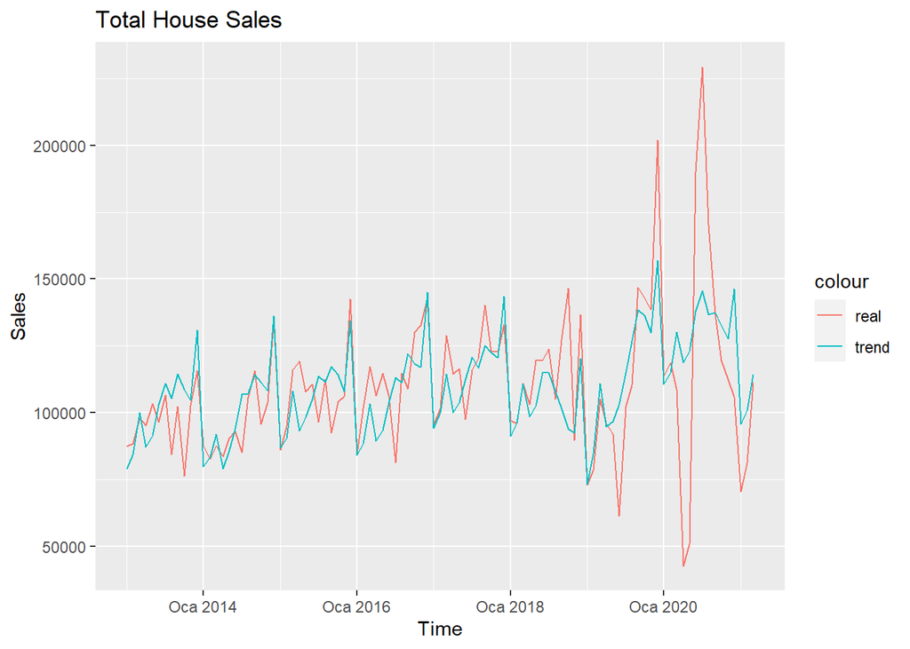

```r
house_sales[,trend_constant_financial_st:=predict(fit,house_sales)]

ggplot(house_sales ,aes(x=Date)) +
 geom_line(aes(y=sales.house_sales,color='real')) +
 geom_line(aes(y=trend_constant_financial_st,color='trend')) + labs(title = "Total House Sales", x = "Time",y = "Sales")
```

## Lagged Variable

```r
house_sales[, residuals:=residuals(fit)]
house_sales[, lag1:=shift(residuals(fit),1)]

fit=lm(sales.house_sales~trend+as.factor(month)+interest_housing+financial_st+lag1,data = house_sales)
summary(fit)
```

```
##
## Call:
## lm(formula = sales.house_sales ~ trend + as.factor(month) + interest_housing +
##     financial_st + lag1, data = house_sales)
##
## Residuals:
##    Min     1Q Median     3Q    Max
## -67469  -8904    735   8221  81288
##
## Coefficients:
##                      Estimate Std. Error t value Pr(>|t|)
## (Intercept)         1.529e+05  6.379e+04   2.396  0.01884 *
## trend               3.913e+02  9.471e+01   4.132 8.63e-05 ***
## as.factor(month)2   5.275e+03  1.011e+04   0.522  0.60337
## as.factor(month)3   1.932e+04  1.012e+04   1.909  0.05980 .
## as.factor(month)4   6.595e+03  1.049e+04   0.629  0.53129
## as.factor(month)5   1.053e+04  1.045e+04   1.008  0.31661
## as.factor(month)6   1.988e+04  1.051e+04   1.891  0.06212 .
## as.factor(month)7   2.882e+04  1.051e+04   2.742  0.00750 **
## as.factor(month)8   2.574e+04  1.056e+04   2.437  0.01698 *
## as.factor(month)9   3.273e+04  1.040e+04   3.147  0.00230 **
## as.factor(month)10  3.043e+04  1.041e+04   2.923  0.00448 **
## as.factor(month)11  2.525e+04  1.040e+04   2.427  0.01741 *
## as.factor(month)12  5.040e+04  1.045e+04   4.821 6.47e-06 ***
## interest_housing   -2.437e+03  5.755e+02  -4.234 5.96e-05 ***
## financial_st       -6.821e+02  8.207e+02  -0.831  0.40828
## lag1                4.185e-01  1.005e-01   4.163 7.71e-05 ***
## ---
## Signif. codes:  0 '***' 0.001 '**' 0.01 '*' 0.05 '.' 0.1 ' ' 1
##
## Residual standard error: 20790 on 82 degrees of freedom
##   (1 observation deleted due to missingness)
## Multiple R-squared:  0.5136, Adjusted R-squared:  0.4247
## F-statistic: 5.773 on 15 and 82 DF,  p-value: 6.41e-08
```

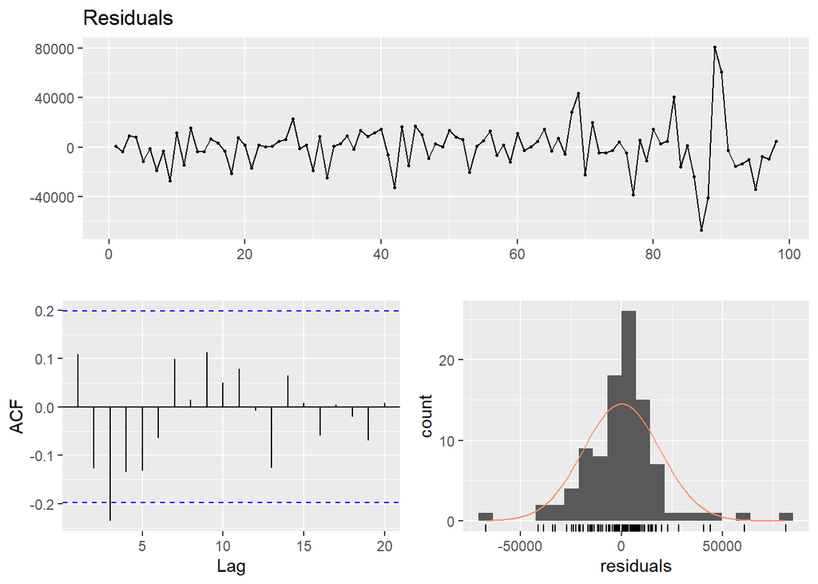

```
##
##  Breusch-Godfrey test for serial correlation of order up to 19
##
## data:  Residuals
## LM test = 34.954, df = 19, p-value = 0.01415
```

```r
checkresiduals(fit)
```

Lag1 has high significance in this model. The p-value decreased compared to previous model, and R-squared value increased. When we check residuals, we see autocorrelation between residuals decreased. Although the p-value is increased, it is enough to reject null hypothesis.

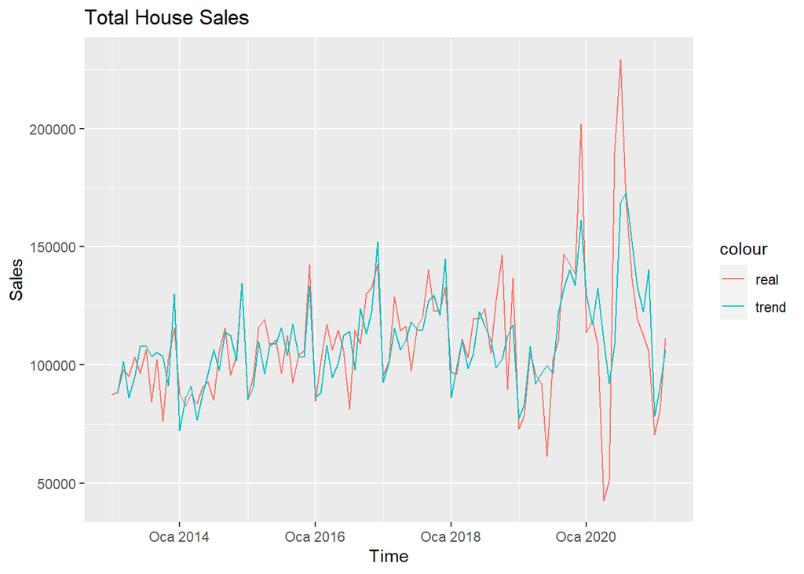

```r
house_sales[,trend_lag1:=predict(fit,house_sales)]

ggplot(house_sales ,aes(x=Date)) +
 geom_line(aes(y=sales.house_sales,color='real')) +
 geom_line(aes(y=trend_lag1,color='trend')) + labs(title = "Total House Sales", x = "Time",y = "Sales")
```

We can see that adding lagged variables made our predictions more accurate.

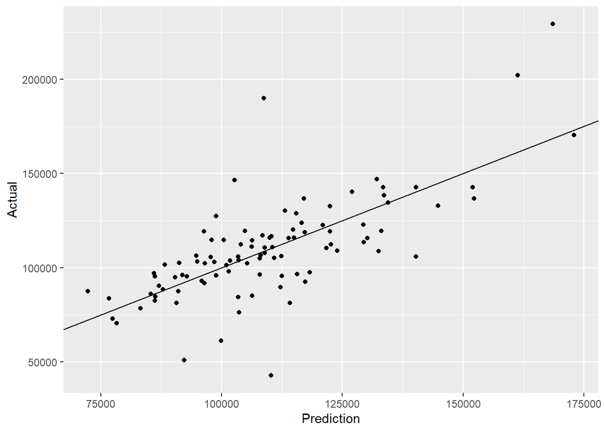

```r
house_sales %>%
  ggplot(aes(x=trend_lag1, y=sales.house_sales)) +
  geom_point()+
geom_abline(slope=1, intercept=0)+labs( x = "Prediction", y = "Actual")
```

Even though, there are some outlier points, most of the points are close to the line.

# Forecasting

```r
house_sales=rbind(house_sales, data.table(Date = as.yearmon("2021-04")),fill=T )
house_sales[,trend:=1:.N]
Model<- arima(house_sales$trend_lag1, c(1,0,0))
forecast1<- predict(Model,n.ahead=1)$pred
forecastfr<- as.data.frame(forecast1)
forecastfr<-unlist(forecastfr)
forecastfr<-as.numeric(forecastfr)
forecastfr
```

```
## [1] 109017.7
```

```r
house_sales[100,12]<-forecastfr[1]
```

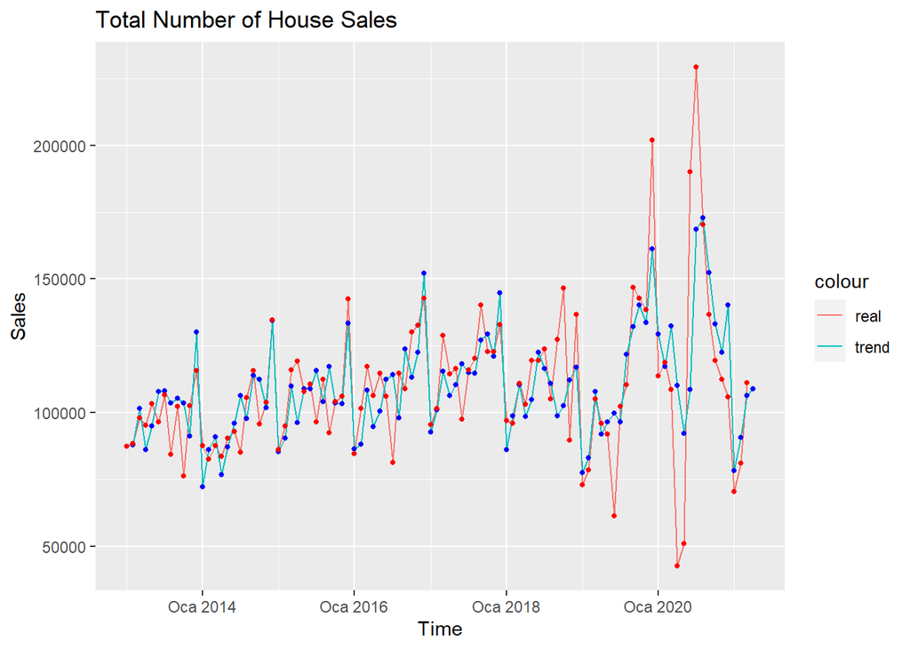

```r
ggplot(house_sales ,aes(x=Date)) +
        geom_line(aes(y=sales.house_sales,color='real')) +
        geom_line(aes(y=trend_lag1,color='trend'))+ geom_point(aes(y=trend_lag1), color = "blue", size = 1) + geom_point(aes(y=sales.house_sales), color = "red", size = 1) + labs(title = "Total Number of House Sales", x = "Time", y = "Sales")
```

# Conclusion